Last year, I did an article [(Resolution Wars: Device Resolution over Time)](https://jotayu.com/tech/2017/08/26/Phone_Resolution/) on resolution changes in newly releases mobile devices over the years. It’s been six months since that article and I think its about time we revisit the current status of that trend.

### About Source Data

We will be using dataset based on [GSMArena](http://www.gsmarena.com/) up to March’2018. This time around our final device count after cleaning and munging data is **8,760** up from 8,314 in last report. I’ve outlined the clean up process in my earlier [article](https://jotayu.com/tech/2017/08/26/Phone_Resolution/), so not repeating it here to keep thing concise and sane.

> 8,760 number of devices in after cleaning data and removing anomalies

### Resolution categorization

For categorizing myriad of resolution, I have divided them in six broad categories with little help from this Wikipedia [page](https://en.wikipedia.org/wiki/Graphics_display_resolution).

| Category | Lower.Limit.Megapixels. | Upper.Limit.Megapixels. |
| --- | --- | --- |
| 1. Below nHD | 0 | 0.22 |
| 2. nHD | 0.23 | 0.51 |
| 3. qHD | 0.52 | 0.91 |
| 4. HD | 0.92 | 2.06 |
| 5. FHD | 2.07 | 3.68 |
| 6. Quad HD | 3.69 | 3.69+ |

So, a phone having a resolution of 1200x1920 (2.3 Megapixels) will be lumped in FHD category because it has got more pixels than FHD(1080x1920 or 2.07 Megapixels) but less than Quad HD (1440x2560 or 3.69 Megapixels).

### Visualization

With all challenges solved, our dataset looks like this-

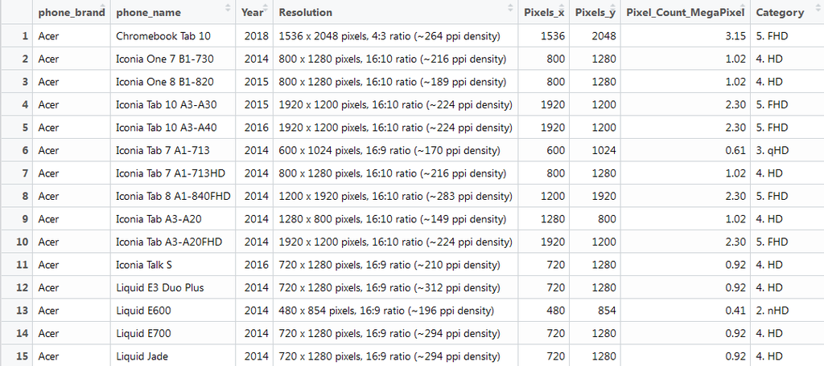

Lets, first plot a stack chart with number of devices in each category since the advent of time (or more precisely, since they started tracking them).2018 is contains data of only 3 months for obvious reasons.

[interactive chart not shown]

> 2016 saw 26% YoY decrease in number of devices released . On 2017 the figure was 21%. With 2018 first quarter gone, I’m expecting a decrease of around 10-12% in 2018 as device manufacturers continue to consolidate and rely on lesser number of products like successful companies like Apple, OnePlus, Oppo etc.

From numbers to share of total devices by resolution category- last time, I did a stack chart scaled to 100% and that was finding it hard to convey the message to my helpful Reddit friends. So, this time introducing a line chart depicting share of devices by each resolution categories.

[interactive chart not shown]

> For the first time, HD devices are observing a decrease in percentile share. FHD & Quad HD is gaining momentum with FHD for the first time became most dominant resolution in Q1’2018. On a surprise twist, qHD devices seems to be making a comeback with increase in share in Q1’2018

And finally, as many of you got accustomed with the previous messy stack thingy, here is the same with 2018 Q1 update.

[interactive chart not shown]

### End Notes

Yes, we are getting resolution hungry with HD becoming old school and FHD/Quad HD devices becoming more dominant. On a surprise twist, we saw an upward tick for lower resolution qHD devices but whether it is an one time trick remains to be seen in coming quarters.

That’s it for today. Stay tuned and keep on commenting and sharing your views.

If you got a data-related challenge worth solving, you can knock me in the links mentioned in profile section and may be we can help each other out.